# Multilayer Perceptron (MLP) Algorithm

by Olusegun Emmanuel Ajibola - olusegunemmanuel.ajibola@student.univaq.it

**Universita degli Studi dell'Aquila**

**Advanced Techniques for Machine Learning**

**Matricola : 281813**

# Introduction

A multilayer perceptron is a neural network connecting multiple layers in a directed graph, which means that the signal path through the nodes only goes one way. Each node, apart from the input nodes, has a nonlinear activation function. An MLP uses backpropagation as a supervised learning technique. Since there are multiple layers of neurons, MLP is a deep learning technique.

MLP is widely used for solving problems that require supervised learning as well as research into computational neuroscience and parallel distributed processing. Applications include speech recognition, image recognition and machine translation.

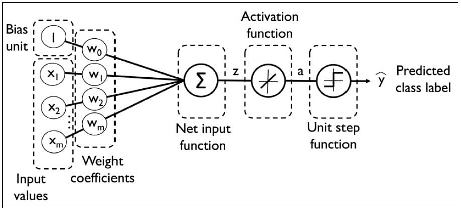

In this project we apply the MLP model to two datasets namely:

- Letters
- Caravan

**Letters Dataset:** The objective is to identify each of a large number of black-and-white rectangular pixel displays as one of the 26 capital letters in the English alphabet. The character images were based on 20 different fonts and each letter within these 20 fonts was randomly distorted to produce a file of 20,000 unique stimuli. Each stimulus was converted into 16 primitive numerical attributes (statistical moments and edge counts) which were then scaled to fit into a range of integer values from 0 through 15. We typically train on the first 16000 items and then use the resulting model to predict the letter category for the remaining 4000.

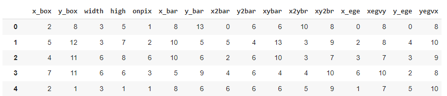

**Caravan Dataset:** This data set includes 85 predictors that measure demographic characteristics for 5,822 individuals.

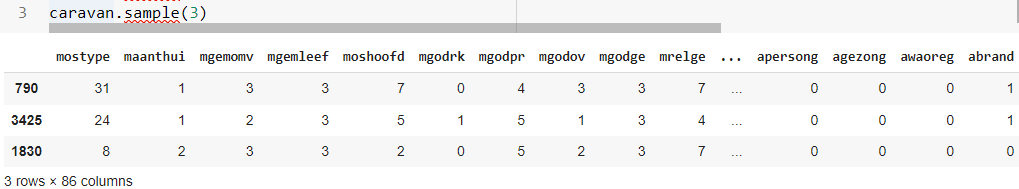

The response variable is Purchase, which indicates whether or not a given individual purchases a caravan insurance policy. In this data set, only 6% of people purchased caravan insurance.

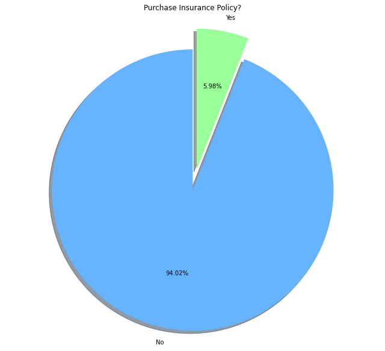

For our datasets, we applied three different MLP models (with relu activation function) architecture namely:

- MLP with 100 units of perceptron.
- MLP with a hour-glass (clessidra) shape.
- MLP with accordion-like.

# Letters Dataset - Results and Discussion.

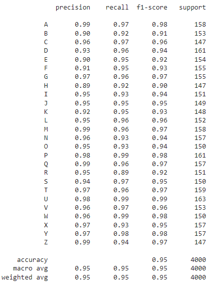

The classification report signifying the f1 and recall scores are given below:

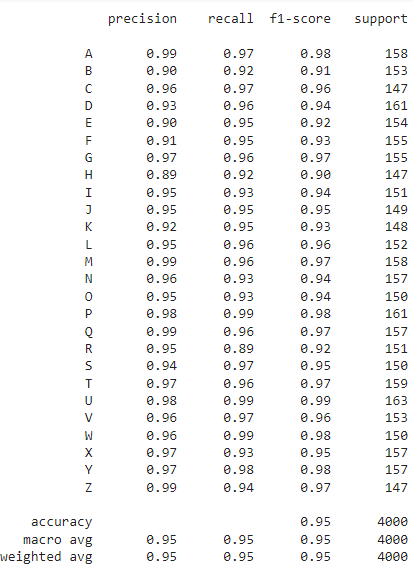

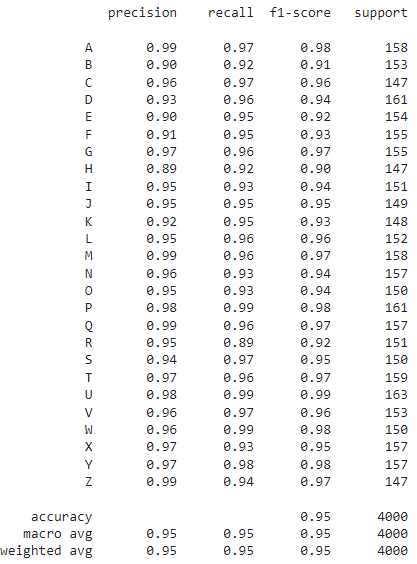

To wrap up our model on the letters dataset, we make use of different k's. Where k represents the columns of our data. This time around, our objective is to see how well the model performs in terms of the test accuracy as we add more columns (i.e k) to the dataset.

Important to note that we used the MLP of 100 perceptrons.

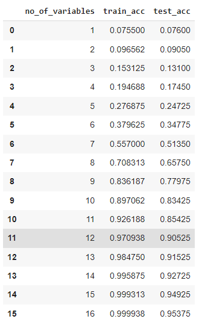

Here, we see how we have sequential jump in accuracy as we increase the k's.

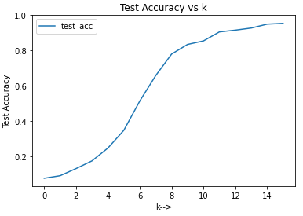

# Caravan Dataset - Results and Discussion.

As we have discussed earlier that the variable of interest in this dataset comprises just 5.98% of the data, we use the MLP model to see if we can improve the prediction to know how many individuals will readily buy our insurance scheme.

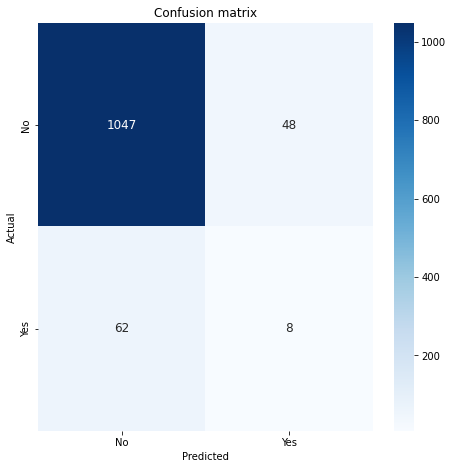

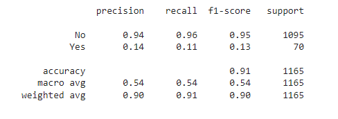

# Conclusion

In this report, we have applied different variants of MLPs to two datasets. One a balanced multiclass dataset of 26 classes and another an imbalanced dataset of 2 class and came to the conclusion that the MLP performs well on balanced data than imbalance data.

Furthermore, as a result of the balance in our letters data, the different architecture of MLPs used in this study gave equivalent result.